# Оценка за курс

## 1. Об отчете

### Исследовательские вопросы

1. Как посещение форума влияет на оценку студента?
2. Как количество посещенных страниц форума влияет на оценку студента?

### Содержание отчета

1. Влияние посещения форума на оценку студента
2. Влияние количества посещенных страниц на оценку студента

### Переменные

- **Посещение форума.**
  - *vis_b* - посещал форум или нет;
  - *vis_p* - количество посещенных страниц форума;
- **Тип курса.**
  - *spec_b* - индивидуальный курс или курс из специализации;
  - *is_prog* - есть задания по программированию в курсе или нет;
- **Оценка**
  - *grade_dum* – выше медианы по курсу (“1”) / ниже медианы по курсу (“0”)

### 1. Форум и оценка

### 1.1 Влияние посещения форума на оценку студента

#### Выбор статистических инструментов:

1. Следует использовать хи-квадрат, поскольку обе переменные категориальные
2. Для расчетов нужно построить перекрестную таблицу

```r
students$grade_dum <- relevel(students$grade_dum, "1")
tab <- table(students$vis_b, students$grade_dum )
tab2 <- students %>% group_by(vis_b, grade_dum) %>%  summarise(n = n()) %>% group_by(vis_b) %>% spread(vis_b, n) %>% rename(visited = "0", not_visited = "1")
tab2
```

```
## # A tibble: 2 x 3
##   grade_dum visited not_visited
##   <fct>       <int>       <int>
## 1 1            7999       14893
## 2 0            5905       11907
```

#### Визуализация перекрестной таблицы двумя способами:

[figure not shown]

[figure not shown]

#### Результат теста хи-квадрат:

```r
chisq
```

```
##
##  Pearson's Chi-squared test with Yates' continuity correction
##
## data:  tab
## X-squared = 14.2, df = 1, p-value = 0.0001643
```

```
## Существует значимая связь между оценками и посещением форума: X-squared = 14.20, p-value = 0.00.
```

Рассчитаем отношение шансов:

```r
visited_high <- tab2$visited[1]
visited_low <- tab2$visited[2]
high_grade_visited <- visited_high / visited_low

not_visited_high <- tab2$not_visited[1]
not_visited_low <- tab2$not_visited[2]
high_grade_not_visited  <- not_visited_high / not_visited_low
high_grade <- high_grade_visited / high_grade_not_visited
high_grade
```

```
## [1] 1.083019
```

```
## Шанс получения высокой оценки после посещения форума равен 1.083 (1.039 и 1.129) к 1, где 1 - это шанс получения высокой оценки без посещения форума
## * высокая оценка = оценка выше медианы по курсу
```

### 1.2 Влияние количества посещенных страниц на оценку студента

#### Выбор статистических инструментов:

1. Следует использовать логистическую регрессию поскольку зависимая переменная имеет только два возможных исхода
2. Для расчетов нужно построить перекрестную таблицу

```r
students$grade_dum <- relevel(students$grade_dum, "0")
m1 <-  glm(grade_dum ~ vis_p, family = "binomial", students)
summary(m1)
```

```
##
## Call:
## glm(formula = grade_dum ~ vis_p, family = "binomial", data = students)
##
## Deviance Residuals:
##    Min      1Q  Median      3Q     Max
## -1.373  -1.276   1.062   1.082   1.082
##
## Coefficients:
##              Estimate Std. Error z value Pr(>|z|)
## (Intercept) 0.2277305  0.0120939  18.830  < 2e-16 ***
## vis_p       0.0003819  0.0001406   2.716  0.00661 **
## ---
## Signif. codes:  0 '***' 0.001 '**' 0.01 '*' 0.05 '.' 0.1 ' ' 1
##
## (Dispersion parameter for binomial family taken to be 1)
##
##     Null deviance: 46621  on 33985  degrees of freedom
## Residual deviance: 46614  on 33984  degrees of freedom
##   (6718 observations deleted due to missingness)
## AIC: 46618
##
## Number of Fisher Scoring iterations: 3
```

```r
prob0<- invlogit(m1$coefficients[1])
prob1<- invlogit(m1$coefficients[1] + m1$coefficients[2])
prob2<- invlogit(m1$coefficients[1] + m1$coefficients[2] * 50)
```

#### Результаты логистической регрессии:

```
## Вероятность получить высокую оценку студентом, который ни разу не посещал форум: 0.5567.
```

```
## Вероятность получить высокую оценку студентом, который один раз посещал форум: 0.5568.
```

Расчет отношения шансов:

```r
odds0 <- prob0/(1-prob0)
odds1 <- prob1/(1-prob1)
odds2 <- prob2/(1-prob2)
ratio = odds1/odds0
# похожие значения можно получить используя exp(m1$coefficients)
ratio_CI <- exp(confint(m1))
```

```
## Шанс получить высокую оценку если не посещал форум: 1.2557 к 1.
```

```
## Шанс получить высокую оценку после посещения одной страницы форума: 1.2562 к 1.
```

[output not shown]

```
## Например, если студент посетил 50 страниц на форуме, то его шанс получить высокую оценку будет: 1.2800 к 1.
```

#### Оценка модели:

```r
modelChi <-  m1$null.deviance - m1$deviance
chidf <- m1$df.null - m1$df.residual
chisq.prob <- 1 - pchisq(modelChi, chidf)
R2.hl = modelChi/m1$null.deviance
R.cs = 1 - exp((m1$deviance - m1$null.deviance )/nrow(m1$data))
R.n = R.cs / (1 - (exp(-(m1$null.deviance/nrow(m1$data)))))
```

```
## Данная модель лучше предсказывает зависимую переменную чем нулевая модель поскольку дисперсия модели (deviance) снизилась с 46621.20 до 46613.79.
```

```
## Добаваление перменной vis_p статистически значимо улучшает модель: x_squared = 7.41, p = 0.0065.
```

```
## Метрики адекватности модели (ПсевдоR2 для логистической регрессии):
## R2 Hosmer-Lemeshov   0.0002
## R2 Cox-Snell     0.0002
## R2 Nagelkerke        0.0003
```

#### Визуализация логистической регрессии

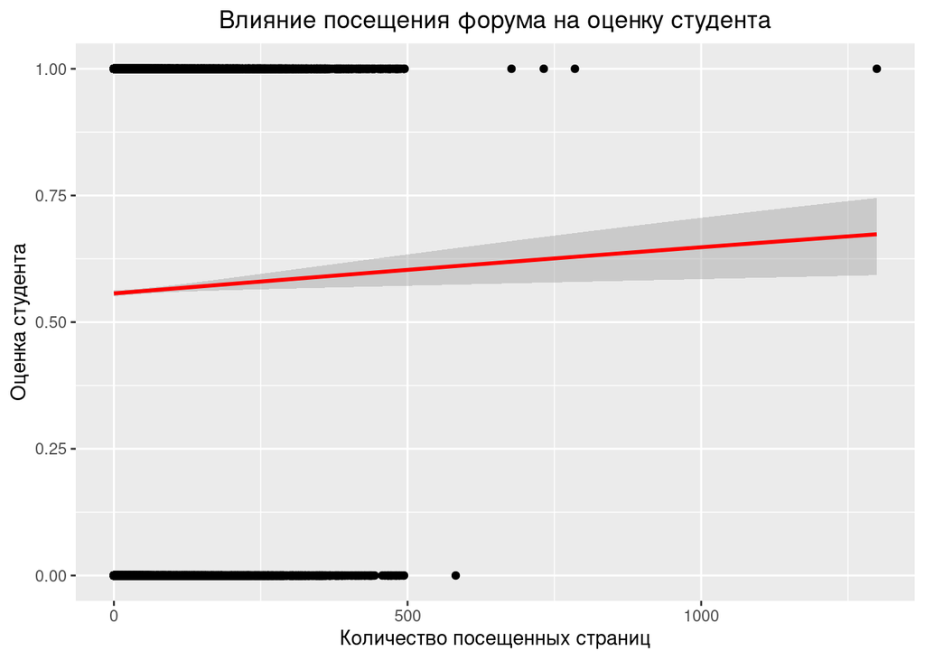

## Выводы

[output not shown]